# POTD 04

Simon Chen

10/19/2021

Run the following code to create a tibble using the `state.x77` data.

```r
# Import libraries.
library(tidyverse)
```

```r
library(ggplot2)
library(magrittr)
# Load the dataset and create a tibble.
dat <- data.frame(state.x77)
dat <- tibble(dat)

# Add the region and division and abbreviation information
dat$Region <- state.region
dat$Division <- state.division
dat$abbrev <- state.abb
print(dat, n = 50, width = 100)
```

```
## # A tibble: 50 × 11
##    Population Income Illiteracy Life.Exp Murder HS.Grad Frost   Area
##         <dbl>  <dbl>      <dbl>    <dbl>  <dbl>   <dbl> <dbl>  <dbl>
##  1       3615   3624        2.1     69.0   15.1    41.3    20  50708
##  2        365   6315        1.5     69.3   11.3    66.7   152 566432
##  3       2212   4530        1.8     70.6    7.8    58.1    15 113417
##  4       2110   3378        1.9     70.7   10.1    39.9    65  51945
##  5      21198   5114        1.1     71.7   10.3    62.6    20 156361
##  6       2541   4884        0.7     72.1    6.8    63.9   166 103766
##  7       3100   5348        1.1     72.5    3.1    56     139   4862
##  8        579   4809        0.9     70.1    6.2    54.6   103   1982
##  9       8277   4815        1.3     70.7   10.7    52.6    11  54090
## 10       4931   4091        2       68.5   13.9    40.6    60  58073
## 11        868   4963        1.9     73.6    6.2    61.9     0   6425
## 12        813   4119        0.6     71.9    5.3    59.5   126  82677
```

[output cut: 90 more lines]

## Task 1

Create a histogram of life expectancy (i.e., including data from all 50 states).  
Did you use binwidth = or bins = and how did you decide on the value?

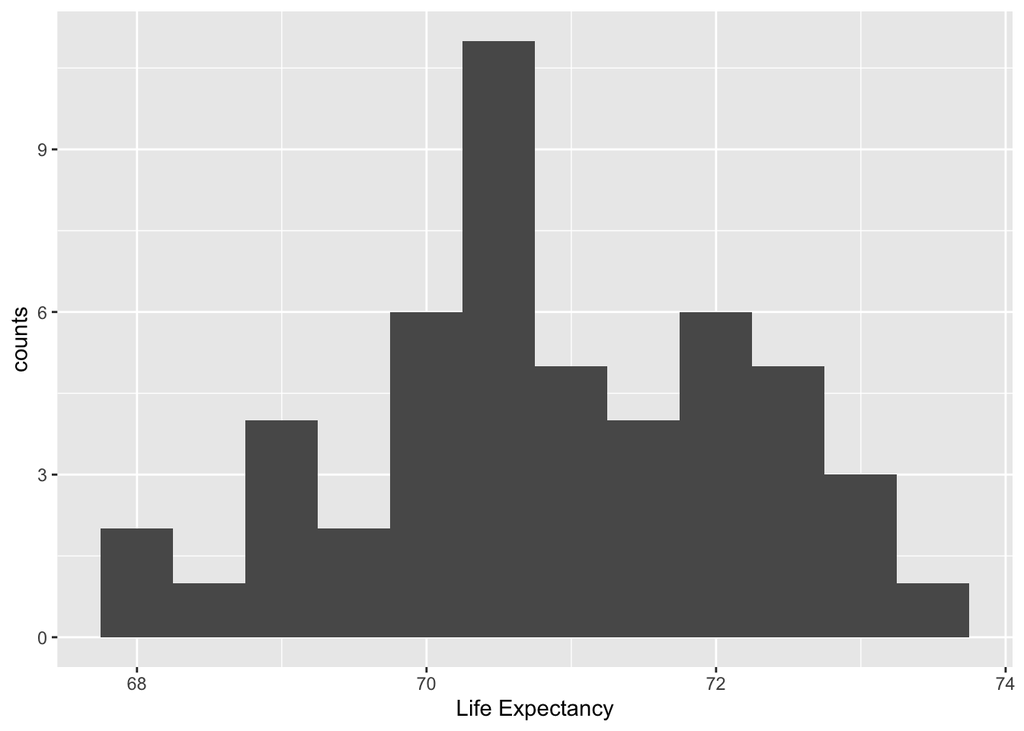

```r
ggplot(data = dat, mapping = aes(x=Life.Exp)) +
  geom_histogram(binwidth = 0.5) +
  xlab('Life Expectancy') +
  ylab('counts')
```

## Task 2

Use group_by() and summary() to determine mean life expectancies and HS grad- uation rates for each region.

```r
group_by(dat, Region) %>%
  summarise(avg_LE = mean(Life.Exp, na.rm = TRUE),
            avg_HS_rate = mean(HS.Grad, na.rm = TRUE))
```

```
## # A tibble: 4 × 3
##   Region        avg_LE avg_HS_rate
##   <fct>          <dbl>       <dbl>
## 1 Northeast       71.3        54.0
## 2 South           69.7        44.3
## 3 North Central   71.8        54.5
## 4 West            71.2        62
```

## Task 3

Use frequency polygons to create histograms of life expectancy by color based on state region, both by count and using density.  
Which do you prefer for these data and why?

I still preferred the counts one, because it’s obviously clear to show the difference.

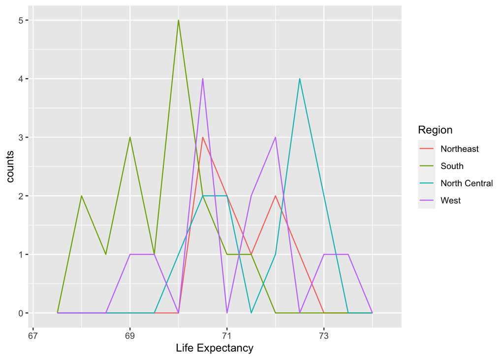

```r
#by counts
ggplot(data = dat, mapping = aes(Life.Exp, color = Region)) +
  geom_freqpoly(binwidth= 0.5) +
  xlab("Life Expectancy") +
  ylab("counts")
```

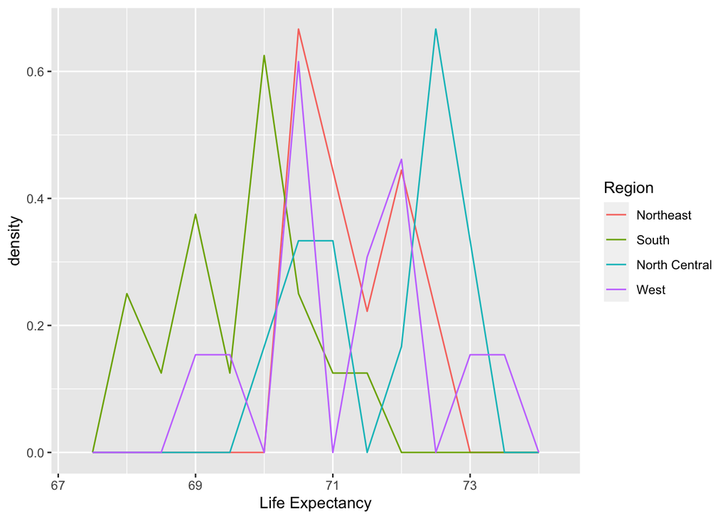

```r
#by density
ggplot(data = dat, mapping = aes(Life.Exp, after_stat(density), color = Region)) +
  geom_freqpoly(binwidth= 0.5) +
  xlab("Life Expectancy") +
  ylab("density")
```

## Task 4

Create conditional box plots of life expectancy by state region (i.e., using the same information as in the previous task).  
What are the pros/cons to using boxplots vs frequency polygons here and in general?

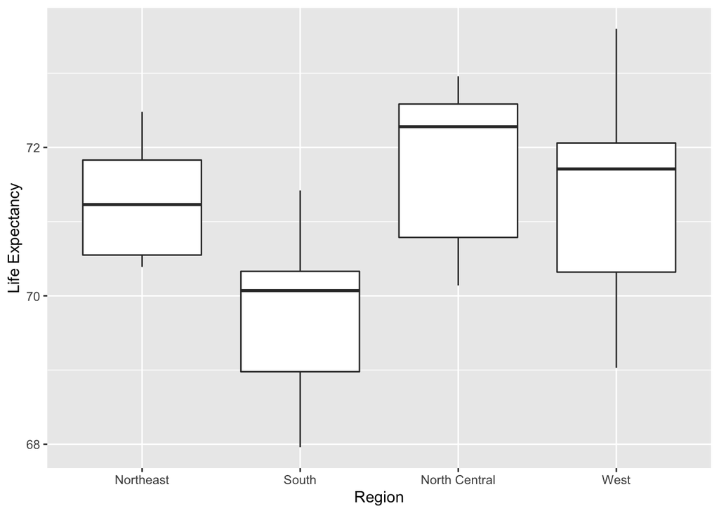

```r
ggplot(data = dat, mapping = aes(Region, Life.Exp)) +
  geom_boxplot() +
  ylab("Life Expectancy") +
  xlab("Region")
```

## Task 5 Replicate the last plot but also order the boxplots by their medians.

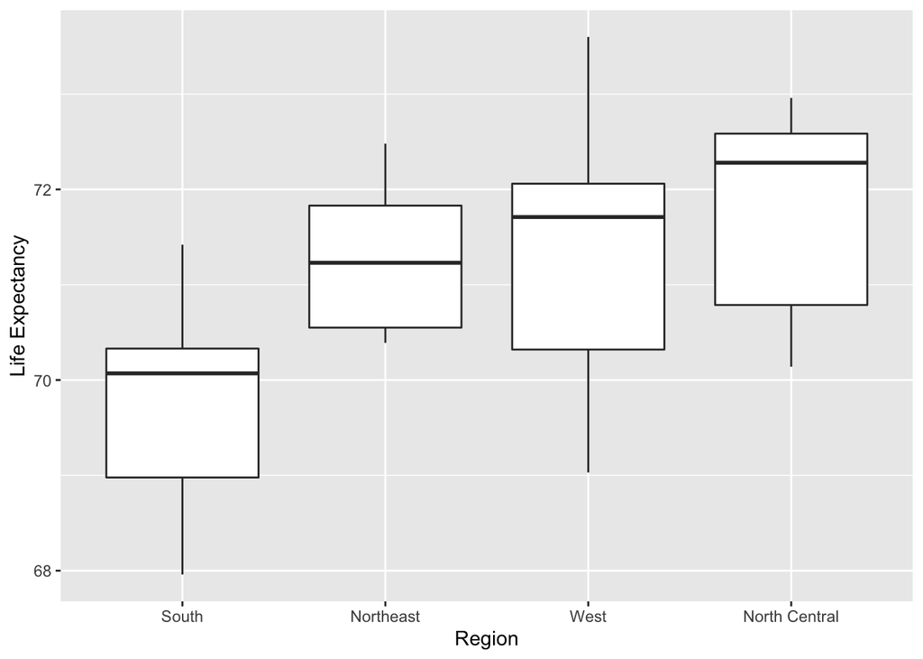

```r
ggplot(data = dat, mapping = aes(x=reorder(Region, Life.Exp, FUN = median), y=Life.Exp)) +
  geom_boxplot() +
  ylab("Life Expectancy") +
  xlab("Region")
```

## Task 6

Create a scatterplot of HS graduation rate on the horizontal axis and life expectancy on the vertical axis.

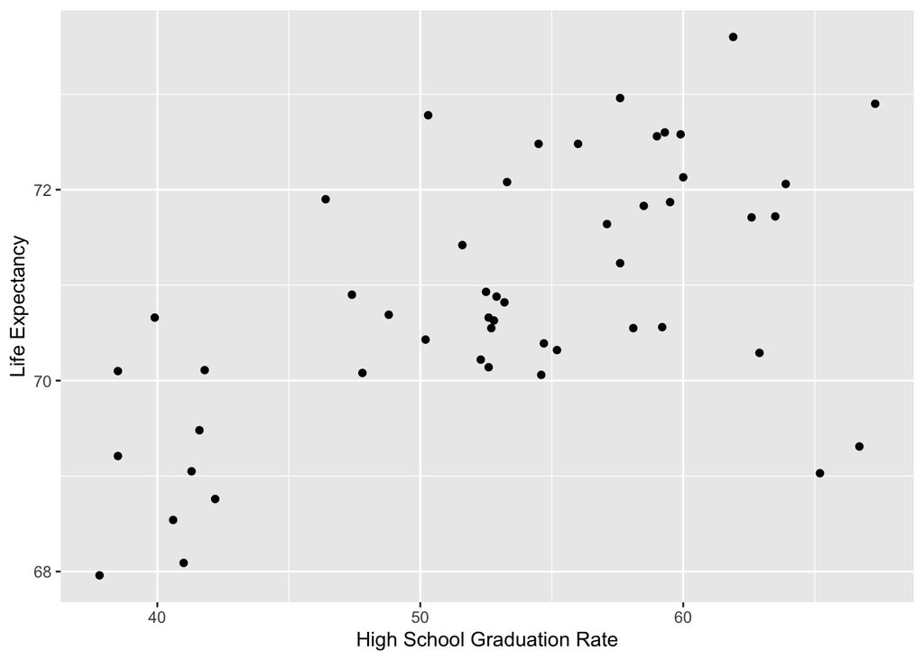

```r
ggplot(data = dat, mapping = aes(x = HS.Grad, y = Life.Exp)) +
  geom_point() +
  ylab("Life Expectancy") +
  xlab("High School Graduation Rate")
```

## Task 7

Replicate the scatterplot directly above using two-letter state abbreviations instead of points for plotting.

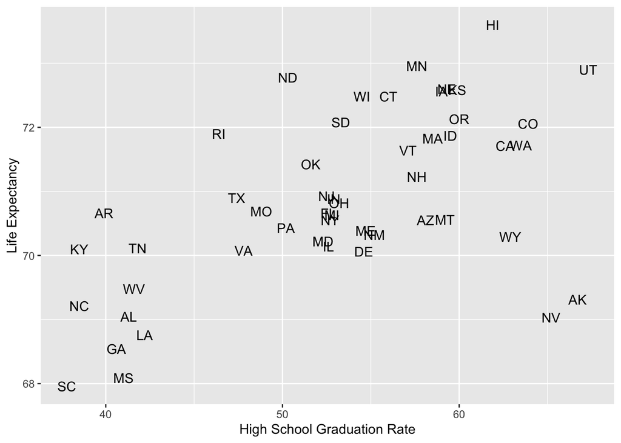

```r
ggplot(data = dat, mapping = aes(x = HS.Grad, y = Life.Exp)) +
  geom_text(aes(label = abbrev)) +
  ylab("Life Expectancy") +
  xlab("High School Graduation Rate")
```

## Task 8

Note that AK and NV are outlying. Use filter(), as in lines 163–169 of ’04_Code.R’, to color those two points blue.

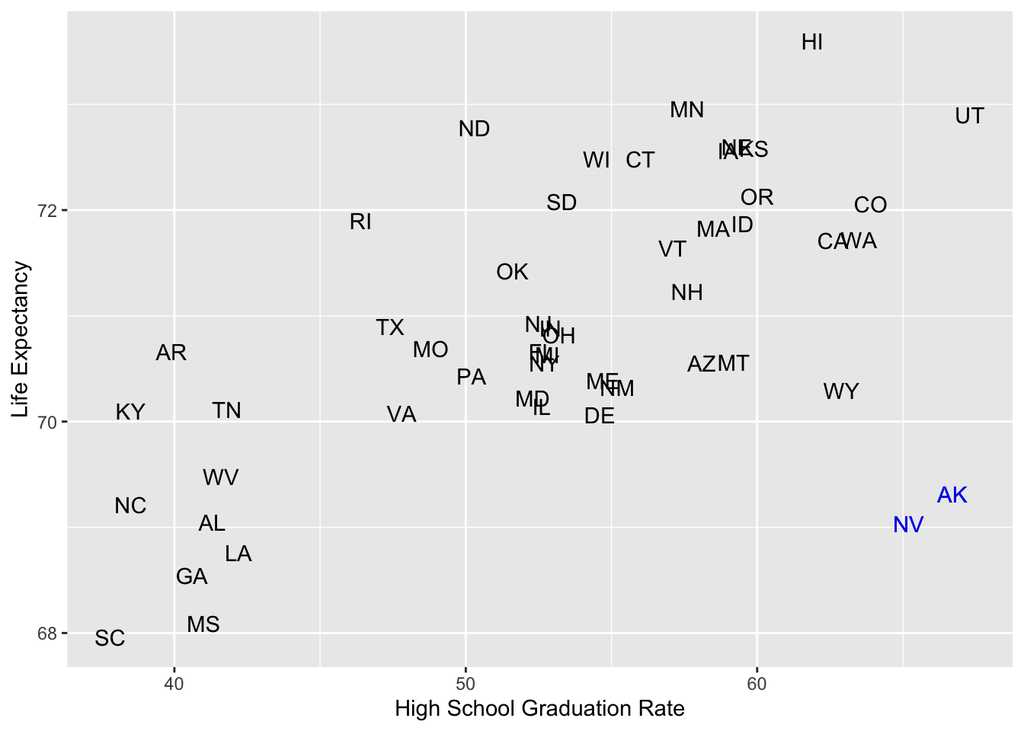

```r
temp <- dat%>%
  filter(abbrev %in% c("AK", "NV"))

ggplot(data = dat, mapping = aes(x = HS.Grad, y = Life.Exp)) +
  geom_text(aes(label = abbrev)) +
  geom_text(data = temp, mapping = aes(x=HS.Grad, y = Life.Exp, label = abbrev), color = "blue") +
  ylab("Life Expectancy") +
  xlab("High School Graduation Rate")
```

## Task 9

Import your project data into R and make a plot of some kind.

Reading data is fine but I need to sort the data then plot them…

```r
# Reading csv data
dat <- read_csv("PTSD_Outcomes_Within_Each_Treatment_Arm.csv")
```

[figure not shown]

```r
dat <- tibble(dat)

ggplot(data = dat, mapping = aes(x = study_id, y = "Total N Randomized")) +
  geom_point() +
  ylab("Total N Randomized") +
  xlab("Study ID")
```